Attribution: this code is modified from `reproducibility.Rmd`. Indicate here if you used ChatGPT or other AI tools to help you write the code.

# Introduction

1. Annotate: explain what you’re doing and *why*
   - using script headers and other Rmarkdown features (like this list!)
   - commenting your code
   - using meaningful & human-readable variable names
2. Automate: make your decisions explicit using code
   - use a scripting language to run your analyses
   - use find+replace to change variable names
   - automate the naming of your output files to include parameter values in the filename
3. Hoard: keep (almost) everything
   - store raw data *and* intermediate steps in data processing
   - store code *and* progress on code (i.e., use version control)
   - backup your work regularly (daily!)
   - note down the exact versions of software and packages
4. Share: provide access to your work
   - save versions using Git
   - use GitHub to upload the versions to their online server

# Run the code

This code multiplies the numbers from 1 to 10 by a constant then saves the output to a comma separated values (`.csv`) file.

```r
# Function to multiply integers from 1 to 10 by a parameter value
get.multiples1to10 <- function(multiplier){
  numbers <- 1:10
  return(multiplier * numbers)
}

# Loop over parameter values 2, 3, and 4
for(current_value in 2:4){
  # Get the multiples
  results <- get.multiples1to10(multiplier = current_value)

  # Construct the filename
  the_filename <- paste("multiples1to10--multiplier", current_value, ".csv")

  # Write the vector directly to CSV
  write.csv(results, file = the_filename, row.names = FALSE)

  sumofall <- 1 + 2 + 3
  print(sumofall)

}
```

```
## [1] 6
## [1] 6
## [1] 6
```

```r
# Calculation for best food

Sashimi <- 10
Burger <- 5
Friedchicken <- 8
```

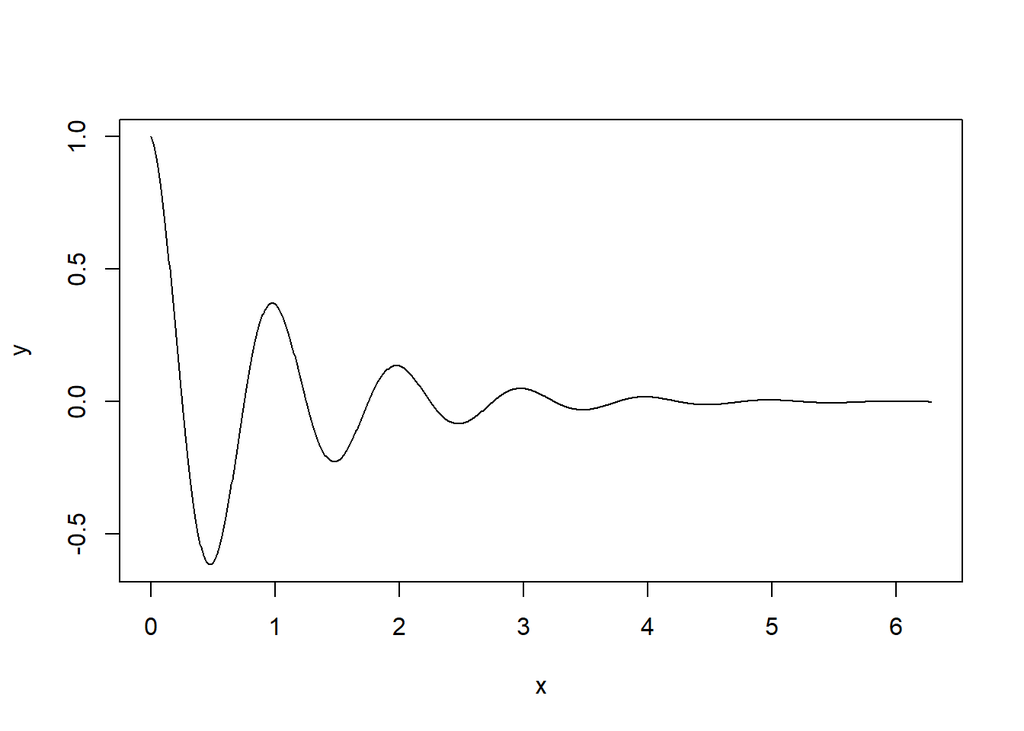

[figure not shown]

```r
# This is a cool plot
x <- seq(0,2*pi, length.out=1000)
y <- exp(-x)*cos(2*pi*x)
plot(x,y,type="l")
```